# Source memory performance for objects inside the rooms

# 1 Visual inspection of the data

# 2 Novelty Benefits

## 2.1 Check the data

**Is there any corrected hit rate < 0?**

There are 3 negative value out of a total of 80 participants.

```
##    SubjectNo    Group MeanCurRt MeanDur     SFHit      SHit     SrcHit
## 1:       P16 Familiar  3.666667     NaN 0.3888889 0.2222222 0.00000000
## 2:       P34 Familiar  2.666667     NaN 0.7222222 0.4444444 0.16666667
## 3:       P39 Familiar  4.000000     NaN 0.9444444 0.6111111 0.05555556
##       SFFalse    SFalse   SrcFalse      SFAcc      SAcc      SrcAcc
## 1: 0.05555556 0.0000000 0.01851852 0.33333333 0.2222222 -0.01851852
## 2: 0.66666667 0.3333333 0.22222222 0.05555556 0.1111111 -0.05555556
## 3: 0.22222222 0.0000000 0.07407407 0.72222222 0.6111111 -0.01851852
```

## 2.2 Compare mean accuracy between *novel* and *familiar* rooms

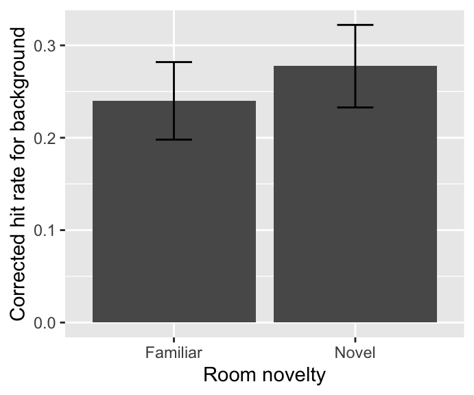

Figure1. Mean accuracy for item memory respectively for Familiar and Novel rooms.

```
##       Group      Mean        SD  N
## 1: Familiar 0.2396651 0.1423118 40
## 2:    Novel 0.2778199 0.1411349 40
```

```
##
##  Paired t-test
##
## data:  SrcAcc by Group
## t = -1.3453, df = 39, p-value = 0.1863
## alternative hypothesis: true difference in means is not equal to 0
## 95 percent confidence interval:
##  -0.09552277  0.01921325
## sample estimates:
## mean of the differences
##             -0.03815476
```

## 2.3 Any difference between *Early* and *Later* object groups?

**Is there any corrected hit rate < 0?**

There are 9 negative values out of a total of 160 participants.

```
##    SubjectNo    Group ObjOrdGrp MeanCurRt  MeanDur     SFHit      SHit
## 1:       P16 Familiar     Early  3.666667      NaN 0.4444444 0.3333333
## 2:       P16 Familiar     Later  3.666667      NaN 0.3333333 0.1111111
## 3:       P30    Novel     Early  4.625000      NaN 0.2500000 0.2500000
## 4:       P34 Familiar     Early  2.666667      NaN 0.6666667 0.4444444
## 5:       P39 Familiar     Early  4.000000      NaN 0.8888889 0.7777778
## 6:       P40    Novel     Later  5.333333      NaN 0.8888889 0.4444444
## 7:       P44    Novel     Later  6.333333 58.17242 0.8888889 0.5555556
## 8:       P52    Novel     Early  5.500000      NaN 1.0000000 1.0000000
## 9:       P52 Familiar     Later  1.500000 84.19194 1.0000000 0.6666667
##       SrcHit    SFFalse     SFalse   SrcFalse       SFAcc      SAcc
## 1: 0.0000000 0.05555556 0.00000000 0.01851852  0.38888889 0.3333333
## 2: 0.0000000 0.05555556 0.00000000 0.01851852  0.27777778 0.1111111
## 3: 0.0000000 0.31818182 0.13636364 0.09090909 -0.06818182 0.1136364
## 4: 0.1111111 0.66666667 0.33333333 0.22222222  0.00000000 0.1111111
## 5: 0.0000000 0.22222222 0.00000000 0.07407407  0.66666667 0.7777778
## 6: 0.0000000 0.05555556 0.00000000 0.01851852  0.83333333 0.4444444
## 7: 0.1111111 0.38888889 0.05555556 0.12962963  0.50000000 0.5000000
## 8: 0.0000000 0.23333333 0.00000000 0.07777778  0.76666667 1.0000000
## 9: 0.0000000 0.23333333 0.00000000 0.07777778  0.76666667 0.6666667
##         SrcAcc
## 1: -0.01851852
## 2: -0.01851852
## 3: -0.09090909
## 4: -0.11111111
## 5: -0.07407407
## 6: -0.01851852
## 7: -0.01851852
## 8: -0.07777778
## 9: -0.07777778
```

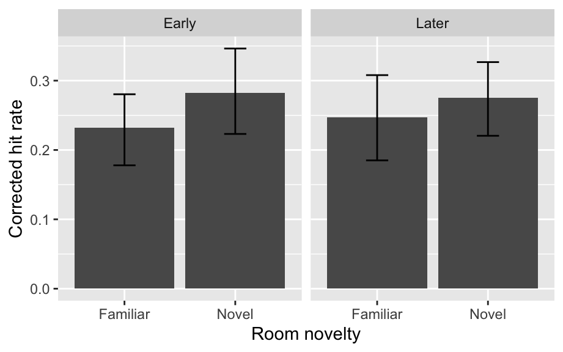

```
##       Group ObjOrdGrp      Mean        SD  N
## 1: Familiar     Early 0.2320262 0.1741649 40
## 2:    Novel     Early 0.2820262 0.2039130 40
## 3:    Novel     Later 0.2750818 0.1697962 40
## 4: Familiar     Later 0.2473040 0.1906984 40
```

```
## $ANOVA
##            Effect DFn DFd          F         p p<.05          ges
## 2           Group   1  39 1.88787355 0.1772878       0.0111863921
## 3       ObjOrdGrp   1  39 0.03065234 0.8619241       0.0001298511
## 4 Group:ObjOrdGrp   1  39 0.14217362 0.7081736       0.0009226535
```

# 3 Curiosity Enhancement

## 3.1 Check the data

### 3.1.1 Is there any corrected hit rate < 0?

#### 3.1.1.1 For the data per room

- There are 27 negative values out of a total of 236 values.

```
##     SubjectNo     Context    Group CurRating RoomOrder  Duration     SFHit
##  1:       P13     Library    Novel         6     First        NA 0.8333333
##  2:       P15     Bedroom Familiar         4     First        NA 0.6666667
##  3:       P16     Bedroom Familiar         4     First        NA 0.5000000
##  4:       P16   Classroom Familiar         2     First        NA 0.1666667
##  5:       P16         Gym Familiar         5    Second        NA 0.5000000
##  6:       P20     Library    Novel         2     First        NA 0.8333333
##  7:       P23   Classroom    Novel         5     First        NA 0.6666667
##  8:       P30     Library    Novel         4     First        NA 0.5000000
##  9:       P30  LivingRoom    Novel         5     First        NA 0.5000000
## 10:       P32   Classroom    Novel         7    Second        NA 0.8333333
## 11:       P32         Gym    Novel         5     First        NA 1.0000000
## 12:       P33         Gym Familiar         1    Second        NA 0.3333333
## 13:       P33  LivingRoom    Novel         6    Second        NA 0.8333333
## 14:       P34     Bedroom Familiar         3    Second        NA 0.5000000
```

[output cut: 72 more lines]

#### 3.1.1.2 For the data per curiosity group

- There are 3 negative value for curiosity group (1 ~ 3 and 5 ~ 7) out of a total of 76 values.

```
##    SubjectNo CurGrp MeanDur     SFHit      SHit    SrcHit    SFFalse
## 1:       P16    Low     NaN 0.1666667 0.1666667 0.0000000 0.05555556
## 2:       P34    Low     NaN 0.7222222 0.4444444 0.1666667 0.66666667
## 3:       P39    Low     NaN 1.0000000 0.6666667 0.0000000 0.22222222
##       SFalse   SrcFalse      SFAcc      SAcc      SrcAcc
## 1: 0.0000000 0.01851852 0.11111111 0.1666667 -0.01851852
## 2: 0.3333333 0.22222222 0.05555556 0.1111111 -0.05555556
## 3: 0.0000000 0.07407407 0.77777778 0.6666667 -0.07407407
```

#### 3.1.1.3 For the data per curiosity group (median)

- There are 3 negative value for curiosity group (median) out of a total of 79 values.

```
##    SubjectNo CurGrpMedian MeanDur     SFHit      SHit    SrcHit    SFFalse
## 1:       P16          Low     NaN 0.3888889 0.2222222 0.0000000 0.05555556
## 2:       P34          Low     NaN 0.7222222 0.4444444 0.1666667 0.66666667
## 3:       P39          Low     NaN 0.9166667 0.5833333 0.0000000 0.22222222
##       SFalse   SrcFalse      SFAcc      SAcc      SrcAcc
## 1: 0.0000000 0.01851852 0.33333333 0.2222222 -0.01851852
## 2: 0.3333333 0.22222222 0.05555556 0.1111111 -0.05555556
## 3: 0.0000000 0.07407407 0.69444444 0.5833333 -0.07407407
```

## 3.2 Mean accuracy of item memory as a function of curiosity rating

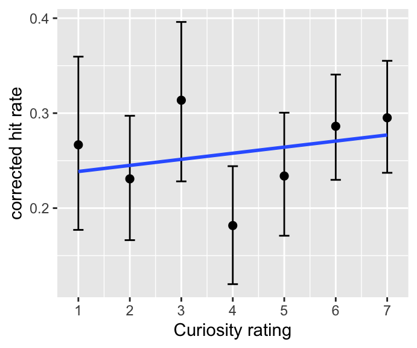

## 3.3 Testing the relationship between mean accuracy of item memory and curiosity rating

Build models with item memory accuracy as $y$ and examine effects of curiosity rating by including it into the model and then comparing the model fits.

- `baseline.rating` is the model with only an intercept, showing no change in item memory as a function of curiosity rating.
- `rating.intercept` is the model with $\small CuriosityRating$ included, showing the effects of curiosity rating.
- `rating.slope` is the model allowing the slope (i.e., relationship between item memory and curiosity rating) varying across participants.

```
##                  Model df       AIC       BIC   logLik   Test  L.Ratio
## baseline.rating      1  3 -91.04211 -80.65061 48.52105
## rating.intercept     2  4 -90.61058 -76.75525 49.30529 1 vs 2 1.568469
## rating.slope         3  6 -88.89895 -68.11596 50.44947 2 vs 3 2.288370
##                  p-value
## baseline.rating
## rating.intercept  0.2104
## rating.slope      0.3185
```

## 3.4 Check the curiosity groups

### 3.4.1 Separate the groups according to the rating

- *High*: curiosity rating > 4
- *Low*: curiosity rating < 4
- For curiosity rating = 4, discarded

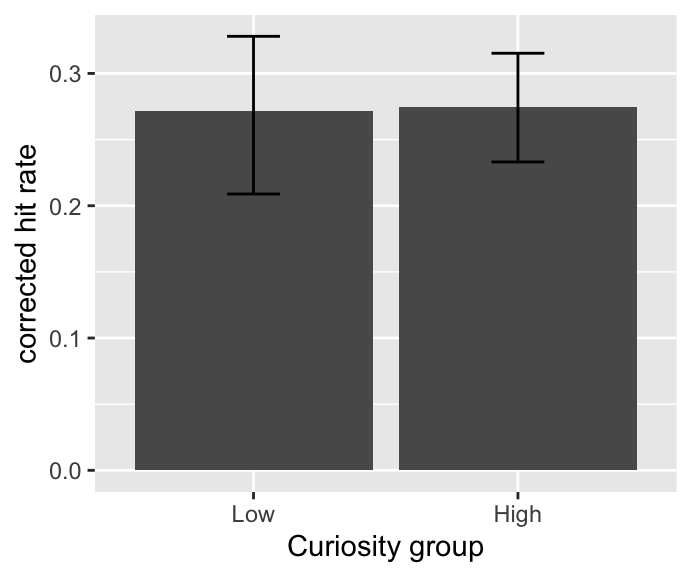

```
##    CurGrp      Mean        SD  N
## 1:   High 0.2748734 0.1359168 40
## 2:    Low 0.2712632 0.1895041 36
```

```
## Linear mixed-effects model fit by maximum likelihood
##  Data: inside.hit.rate.curiosity.group
##         AIC       BIC   logLik
##   -54.12363 -40.13923 33.06181
##
## Random effects:
##  Formula: ~1 + CurGrp | SubjectNo
##  Structure: General positive-definite, Log-Cholesky parametrization
##             StdDev     Corr
## (Intercept) 0.17187302 (Intr)
## CurGrpHigh  0.19217519 -0.815
## Residual    0.07352687
##
## Fixed effects: SrcAcc ~ CurGrp
##                  Value  Std.Error DF  t-value p-value
## (Intercept) 0.26969720 0.03155783 39 8.546127  0.0000
## CurGrpHigh  0.00517624 0.03639330 35 0.142231  0.8877
##  Correlation:
##            (Intr)
## CurGrpHigh -0.809
##
## Standardized Within-Group Residuals:
##          Min           Q1          Med           Q3          Max
## -0.978283713 -0.369596198 -0.001072544  0.317428140  1.113454848
##
## Number of Observations: 76
## Number of Groups: 40
```

#### 3.4.1.1 Curiosity groups and temporal order of the objects

##### 3.4.1.1.1 Check the data

- **Is there any corrected hit rate < 0?**
  - There are 12 negative values out of a total of 152 values.

```
##     SubjectNo CurGrp ObjOrdGrp     SFHit      SHit     SrcHit    SFFalse
##  1:       P16    Low     Early 0.3333333 0.3333333 0.00000000 0.05555556
##  2:       P16    Low     Later 0.0000000 0.0000000 0.00000000 0.05555556
##  3:       P19    Low     Later 0.5000000 0.5000000 0.00000000 0.16666667
##  4:       P20    Low     Later 1.0000000 1.0000000 0.00000000 0.22222222
##  5:       P23   High     Early 0.7500000 0.6666667 0.08333333 0.33333333
##  6:       P34    Low     Early 0.6666667 0.4444444 0.11111111 0.66666667
##  7:       P39    Low     Early 1.0000000 1.0000000 0.00000000 0.22222222
##  8:       P39    Low     Later 1.0000000 0.3333333 0.00000000 0.22222222
##  9:       P40   High     Later 0.8888889 0.4444444 0.00000000 0.05555556
## 10:       P44   High     Later 0.8888889 0.5555556 0.11111111 0.38888889
## 11:       P52   High     Early 1.0000000 1.0000000 0.00000000 0.23333333
## 12:       P52    Low     Later 1.0000000 0.6666667 0.00000000 0.23333333
##         SFalse   SrcFalse       SFAcc      SAcc       SrcAcc
##  1: 0.00000000 0.01851852  0.27777778 0.3333333 -0.018518519
##  2: 0.00000000 0.01851852 -0.05555556 0.0000000 -0.018518519
##  3: 0.05555556 0.05555556  0.33333333 0.4444444 -0.055555556
##  4: 0.22222222 0.07407407  0.77777778 0.7777778 -0.074074074
##  5: 0.11111111 0.09259259  0.41666667 0.5555556 -0.009259259
##  6: 0.33333333 0.22222222  0.00000000 0.1111111 -0.111111111
##  7: 0.00000000 0.07407407  0.77777778 1.0000000 -0.074074074
##  8: 0.00000000 0.07407407  0.77777778 0.3333333 -0.074074074
##  9: 0.00000000 0.01851852  0.83333333 0.4444444 -0.018518519
## 10: 0.05555556 0.12962963  0.50000000 0.5000000 -0.018518519
## 11: 0.00000000 0.07777778  0.76666667 1.0000000 -0.077777778
## 12: 0.00000000 0.07777778  0.76666667 0.6666667 -0.077777778
```

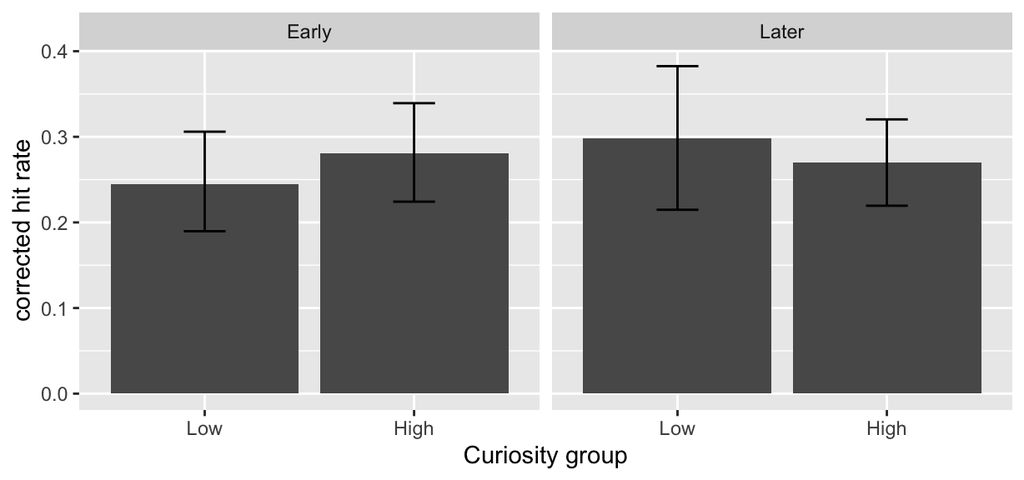

```
##    CurGrp ObjOrdGrp      Mean        SD  N
## 1:   High     Early 0.2803217 0.1876540 40
## 2:   High     Later 0.2698040 0.1592429 40
## 3:    Low     Later 0.2978836 0.2683901 36
## 4:    Low     Early 0.2446429 0.1869216 36
```

```
##           Model df       AIC       BIC   logLik   Test   L.Ratio p-value
## baseline      1  8 -56.50329 -32.31224 36.25164
## ord.model     2  9 -55.13365 -27.91872 36.56682 1 vs 2 0.6303633  0.4272
## cur.model     3 10 -53.15646 -22.91765 36.57823 2 vs 3 0.0228107  0.8800
## int.model     4 11 -52.84345 -19.58076 37.42172 3 vs 4 1.6869876  0.1940
```

```
## Linear mixed-effects model fit by maximum likelihood
##  Data: inside.hit.rate.item.order.curiosity[!is.na(CurGrp)]
##         AIC       BIC   logLik
##   -52.84345 -19.58076 37.42172
##
## Random effects:
##  Formula: ~1 + CurGrp + ObjOrdGrp | SubjectNo
##  Structure: General positive-definite, Log-Cholesky parametrization
##                StdDev     Corr
## (Intercept)    0.12099076 (Intr) CrGrpH
## CurGrpHigh     0.16152598 -0.727
## ObjOrdGrpLater 0.08884641  0.589 -0.975
## Residual       0.15409563
##
## Fixed effects: SrcAcc ~ ObjOrdGrp + CurGrp + ObjOrdGrp:CurGrp
##                                 Value  Std.Error  DF   t-value p-value
## (Intercept)                0.24250075 0.03302187 109  7.343640  0.0000
## ObjOrdGrpLater             0.05536039 0.03968940 109  1.394841  0.1659
## CurGrpHigh                 0.03782092 0.04465602 109  0.846939  0.3989
## ObjOrdGrpLater:CurGrpHigh -0.06587807 0.05091104 109 -1.293984  0.1984
##  Correlation:
##                           (Intr) ObjOGL CrGrpH
## ObjOrdGrpLater            -0.379
## CurGrpHigh                -0.732  0.170
## ObjOrdGrpLater:CurGrpHigh  0.393 -0.679 -0.558
##
## Standardized Within-Group Residuals:
##         Min          Q1         Med          Q3         Max
## -1.97283393 -0.56138503 -0.03904505  0.57502893  2.20043885
##
## Number of Observations: 152
## Number of Groups: 40
```

##### 3.4.1.1.2 *Post hoc*

```
##
##   Simultaneous Tests for General Linear Hypotheses
##
## Fit: lme.formula(fixed = SrcAcc ~ ObjOrdGrp + CurGrp + ObjOrdGrp:CurGrp,
##     data = inside.hit.rate.item.order.curiosity[!is.na(CurGrp)],
##     random = ~1 + CurGrp + ObjOrdGrp | SubjectNo, method = "ML",
##     na.action = na.exclude, control = list(msMaxIter = 500, opt = "optim",
##         msVerbose = FALSE))
##
## Linear Hypotheses:
##                          Estimate Std. Error z value Pr(>|z|)
## Early: High vs. Low == 0  0.03782    0.04406   0.858    0.391
## Late:  High vs. Low == 0 -0.02806    0.04464  -0.628    0.530
## (Adjusted p values reported -- none method)
```

### 3.4.2 Separate the groups according to the median rating of each participant

- *High*: curiosity rating > median of the participant
- *Low*: curiosity rating < median of the participant

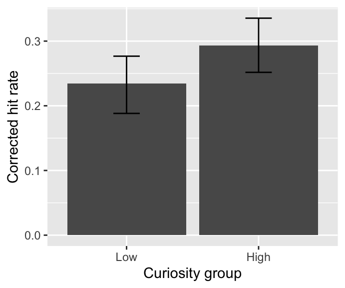

```
## Linear mixed-effects model fit by maximum likelihood
##  Data: inside.hit.rate.curiosity.group.median
##         AIC       BIC   logLik
##   -71.06607 -56.84938 41.53303
##
## Random effects:
##  Formula: ~1 + CurGrpMedian | SubjectNo
##  Structure: General positive-definite, Log-Cholesky parametrization
##                  StdDev     Corr
## (Intercept)      0.13515170 (Intr)
## CurGrpMedianHigh 0.17128696 -0.713
## Residual         0.06460561
##
## Fixed effects: SrcAcc ~ CurGrpMedian
##                       Value  Std.Error DF  t-value p-value
## (Intercept)      0.23410955 0.02399100 39 9.758225  0.0000
## CurGrpMedianHigh 0.05915699 0.03128714 38 1.890777  0.0663
##  Correlation:
##                  (Intr)
## CurGrpMedianHigh -0.707
##
## Standardized Within-Group Residuals:
##         Min          Q1         Med          Q3         Max
## -0.95221515 -0.37896641  0.02459752  0.28343651  1.16487731
##
## Number of Observations: 79
## Number of Groups: 40
```

#### 3.4.2.1 Curiosity groups and temporal order of the objects

##### 3.4.2.1.1 Check the data

- **Is there any corrected hit rate < 0?**
  - There are 12 negative values out of a total of 158 participants.

```
##     SubjectNo CurGrpMedian ObjOrdGrp     SFHit      SHit    SrcHit
##  1:       P16          Low     Early 0.4444444 0.3333333 0.0000000
##  2:       P16          Low     Later 0.3333333 0.1111111 0.0000000
##  3:       P20          Low     Later 1.0000000 1.0000000 0.0000000
##  4:       P23          Low     Later 0.7777778 0.6666667 0.0000000
##  5:       P30          Low     Early 0.5000000 0.3333333 0.0000000
##  6:       P34          Low     Early 0.6666667 0.4444444 0.1111111
##  7:       P39          Low     Later 1.0000000 0.5000000 0.0000000
##  8:       P39          Low     Early 0.8333333 0.6666667 0.0000000
##  9:       P40         High     Later 0.8888889 0.4444444 0.0000000
## 10:       P44         High     Later 0.8888889 0.5555556 0.1111111
## 11:       P52         High     Early 1.0000000 1.0000000 0.0000000
## 12:       P52          Low     Later 1.0000000 0.6666667 0.0000000
##        SFFalse     SFalse   SrcFalse     SFAcc      SAcc      SrcAcc
##  1: 0.05555556 0.00000000 0.01851852 0.3888889 0.3333333 -0.01851852
##  2: 0.05555556 0.00000000 0.01851852 0.2777778 0.1111111 -0.01851852
##  3: 0.22222222 0.22222222 0.07407407 0.7777778 0.7777778 -0.07407407
##  4: 0.33333333 0.11111111 0.09259259 0.4444444 0.5555556 -0.09259259
##  5: 0.31818182 0.13636364 0.09090909 0.1818182 0.1969697 -0.09090909
##  6: 0.66666667 0.33333333 0.22222222 0.0000000 0.1111111 -0.11111111
##  7: 0.22222222 0.00000000 0.07407407 0.7777778 0.5000000 -0.07407407
##  8: 0.22222222 0.00000000 0.07407407 0.6111111 0.6666667 -0.07407407
##  9: 0.05555556 0.00000000 0.01851852 0.8333333 0.4444444 -0.01851852
## 10: 0.38888889 0.05555556 0.12962963 0.5000000 0.5000000 -0.01851852
## 11: 0.23333333 0.00000000 0.07777778 0.7666667 1.0000000 -0.07777778
## 12: 0.23333333 0.00000000 0.07777778 0.7666667 0.6666667 -0.07777778
```

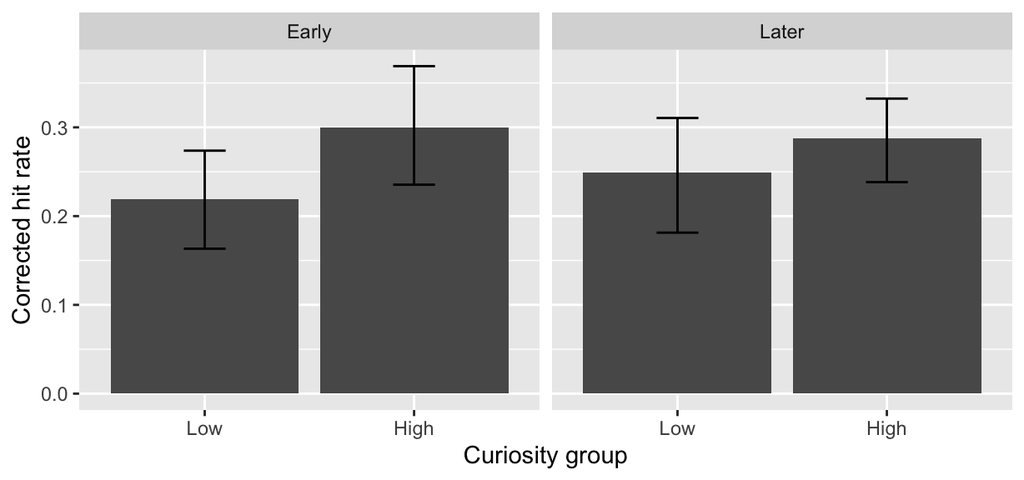

```
##    CurGrpMedian ObjOrdGrp      Mean        SD  N
## 1:          Low     Early 0.2195262 0.1746413 40
## 2:         High     Early 0.3001357 0.2081213 39
## 3:         High     Later 0.2873152 0.1655694 39
## 4:          Low     Later 0.2486929 0.2092428 40
```

```
##           Model df       AIC       BIC   logLik   Test  L.Ratio p-value
## baseline      1  8 -65.66277 -41.16201 40.83139
## ord.model     2  9 -64.32334 -36.75999 41.16167 1 vs 2 0.660570  0.4164
## cur.model     3 10 -65.70571 -35.07976 42.85285 2 vs 3 3.382362  0.0659
## int.model     4 11 -64.39012 -30.70157 43.19506 3 vs 4 0.684411  0.4081
```

```
## Linear mixed-effects model fit by maximum likelihood
##  Data: inside.hit.rate.item.order.curiosity.median[!is.na(CurGrpMedian)]
##         AIC       BIC   logLik
##   -65.70571 -35.07976 42.85285
##
## Random effects:
##  Formula: ~1 + CurGrpMedian + ObjOrdGrp | SubjectNo
##  Structure: General positive-definite, Log-Cholesky parametrization
##                  StdDev     Corr
## (Intercept)      0.07167408 (Intr) CrGrMH
## CurGrpMedianHigh 0.11481394 -0.529
## ObjOrdGrpLater   0.07611018  0.633 -0.985
## Residual         0.16124801
##
## Fixed effects: SrcAcc ~ ObjOrdGrp + CurGrpMedian
##                       Value  Std.Error  DF  t-value p-value
## (Intercept)      0.22999812 0.02510207 116 9.162515  0.0000
## ObjOrdGrpLater   0.00822285 0.02862185 116 0.287293  0.7744
## CurGrpMedianHigh 0.05892781 0.03179237 116 1.853520  0.0663
##  Correlation:
##                  (Intr) ObjOGL
## ObjOrdGrpLater   -0.345
## CurGrpMedianHigh -0.554 -0.242
##
## Standardized Within-Group Residuals:
##         Min          Q1         Med          Q3         Max
## -2.01761435 -0.61425953 -0.07238359  0.61630113  2.16479485
##
## Number of Observations: 158
## Number of Groups: 40
```

##### 3.4.2.1.2 *Post hoc*

```
##
##   Simultaneous Tests for General Linear Hypotheses
##
## Fit: lme.formula(fixed = SrcAcc ~ ObjOrdGrp + CurGrpMedian + ObjOrdGrp:CurGrpMedian,
##     data = inside.hit.rate.item.order.curiosity.median[!is.na(CurGrpMedian)],
##     random = ~1 + CurGrpMedian + ObjOrdGrp | SubjectNo, method = "ML",
##     na.action = na.exclude, control = list(msMaxIter = 500, opt = "optim",
##         msVerbose = FALSE))
##
## Linear Hypotheses:
##                          Estimate Std. Error z value Pr(>|z|)
## Early: High vs. Low == 0  0.08017    0.04052   1.978   0.0479 *
## Late:  High vs. Low == 0  0.03770    0.04048   0.931   0.3517
## ---
## Signif. codes:  0 '***' 0.001 '**' 0.01 '*' 0.05 '.' 0.1 ' ' 1
## (Adjusted p values reported -- none method)
```

# 4 **Novelty** or **Curiosity**?

## 4.1 For Curiosity group splitted by score (*Low*: 1 ~ 3; *High*: 5 ~ 7)

### 4.1.1 Curiosity first, novelty next

```
##               Model df       AIC       BIC   logLik   Test   L.Ratio
## base.model        1  8 -70.16066 -43.49891 43.08033
## cur.scr.model     2  9 -68.16121 -38.16674 43.08060 1 vs 2 0.0005492
## nov.scr.model     3 10 -68.80418 -35.47699 44.40209 2 vs 3 2.6429721
##               p-value
## base.model
## cur.scr.model  0.9813
## nov.scr.model  0.1040
```

```
## Linear mixed-effects model fit by maximum likelihood
##  Data: inside.hit.rate.per.room[!is.na(CurGrp)]
##         AIC       BIC  logLik
##   -68.16121 -38.16674 43.0806
##
## Random effects:
##  Formula: ~1 + CurGrp + Group | SubjectNo
##  Structure: General positive-definite, Log-Cholesky parametrization
##             StdDev     Corr
## (Intercept) 0.05378586 (Intr) CrGrpL
## CurGrpLow   0.12627775 -0.446
## GroupNovel  0.08213702  0.038  0.355
## Residual    0.17426478
##
## Fixed effects: SrcAcc ~ CurGrp
##                   Value  Std.Error  DF   t-value p-value
## (Intercept)  0.26547124 0.02117619 166 12.536311  0.0000
## CurGrpLow   -0.00079738 0.03265192 166 -0.024421  0.9805
##  Correlation:
##           (Intr)
## CurGrpLow -0.538
##
## Standardized Within-Group Residuals:
##         Min          Q1         Med          Q3         Max
## -2.06171236 -0.69506897  0.03838871  0.65024735  3.28551204
##
## Number of Observations: 207
## Number of Groups: 40
```

### 4.1.2 Novelty first, curiosity next

```
##               Model df       AIC       BIC   logLik   Test  L.Ratio
## base.model        1  8 -70.16066 -43.49891 43.08033
## nov.scr.model     2  9 -69.38264 -39.38817 43.69132 1 vs 2 1.221978
## cur.scr.model     3 10 -68.80418 -35.47699 44.40209 2 vs 3 1.421543
##               p-value
## base.model
## nov.scr.model  0.2690
## cur.scr.model  0.2331
```

```
## Linear mixed-effects model fit by maximum likelihood
##  Data: inside.hit.rate.per.room[!is.na(CurGrp)]
##         AIC       BIC   logLik
##   -69.38264 -39.38817 43.69132
##
## Random effects:
##  Formula: ~1 + CurGrp + Group | SubjectNo
##  Structure: General positive-definite, Log-Cholesky parametrization
##             StdDev     Corr
## (Intercept) 0.05119982 (Intr) CrGrpL
## CurGrpLow   0.13528215 -0.536
## GroupNovel  0.06835235  0.345  0.400
## Residual    0.17361593
##
## Fixed effects: SrcAcc ~ Group
##                  Value  Std.Error  DF   t-value p-value
## (Intercept) 0.24784946 0.02361003 166 10.497635  0.0000
## GroupNovel  0.03353973 0.02977363 166  1.126491  0.2616
##  Correlation:
##            (Intr)
## GroupNovel -0.653
##
## Standardized Within-Group Residuals:
##         Min          Q1         Med          Q3         Max
## -2.13190366 -0.68721950  0.06073732  0.62239125  3.25288058
##
## Number of Observations: 207
## Number of Groups: 40
```

## 4.2 For Curiosity group splitted by individual medians

### 4.2.1 Curiosity first, novelty next

```
##              Model df       AIC       BIC   logLik   Test   L.Ratio
## base.model       1  8 -82.79002 -55.39042 49.39501
## cur.md.model     2  9 -83.85061 -53.02606 50.92530 1 vs 2 3.0605852
## nov.md.model     3 10 -82.06331 -47.81381 51.03166 2 vs 3 0.2127042
##              p-value
## base.model
## cur.md.model  0.0802
## nov.md.model  0.6447
```

```
## Linear mixed-effects model fit by maximum likelihood
##  Data: inside.hit.rate.per.room[!is.na(CurGrpMedian)]
##         AIC       BIC  logLik
##   -83.85061 -53.02606 50.9253
##
## Random effects:
##  Formula: ~1 + CurGrpMedian + Group | SubjectNo
##  Structure: General positive-definite, Log-Cholesky parametrization
##                 StdDev     Corr
## (Intercept)     0.05947143 (Intr) CrGrML
## CurGrpMedianLow 0.13861786 -0.705
## GroupNovel      0.06284231  0.208  0.429
## Residual        0.17158123
##
## Fixed effects: SrcAcc ~ CurGrpMedian
##                       Value  Std.Error  DF   t-value p-value
## (Intercept)      0.29156717 0.02190721 186 13.309189  0.0000
## CurGrpMedianLow -0.05482908 0.03061301 186 -1.791039  0.0749
##  Correlation:
##                 (Intr)
## CurGrpMedianLow -0.64
##
## Standardized Within-Group Residuals:
##         Min          Q1         Med          Q3         Max
## -1.92448007 -0.66653379  0.04708726  0.60117970  3.28628678
##
## Number of Observations: 227
## Number of Groups: 40
```

### 4.2.2 Novelty first, curiosity next

```
##              Model df       AIC       BIC   logLik   Test  L.Ratio p-value
## base.model       1  8 -82.79002 -55.39042 49.39501
## nov.md.model     2  9 -82.64308 -51.81853 50.32154 1 vs 2 1.853052  0.1734
## cur.md.model     3 10 -82.06331 -47.81381 51.03166 2 vs 3 1.420237  0.2334
```

```
## Linear mixed-effects model fit by maximum likelihood
##  Data: inside.hit.rate.per.room[!is.na(CurGrpMedian)]
##         AIC       BIC   logLik
##   -82.64308 -51.81853 50.32154
##
## Random effects:
##  Formula: ~1 + CurGrpMedian + Group | SubjectNo
##  Structure: General positive-definite, Log-Cholesky parametrization
##                 StdDev     Corr
## (Intercept)     0.07187576 (Intr) CrGrML
## CurGrpMedianLow 0.17159757 -0.947
## GroupNovel      0.10639241 -0.480  0.683
## Residual        0.17124095
##
## Fixed effects: SrcAcc ~ Group
##                  Value  Std.Error  DF   t-value p-value
## (Intercept) 0.24505351 0.02202590 186 11.125696  0.0000
## GroupNovel  0.04275764 0.02958757 186  1.445122  0.1501
##  Correlation:
##            (Intr)
## GroupNovel -0.654
##
## Standardized Within-Group Residuals:
##        Min         Q1        Med         Q3        Max
## -1.9124711 -0.6399195  0.0658422  0.6192870  3.3021198
##
## Number of Observations: 227
## Number of Groups: 40
```